# MPDW 5

Reyzha Siva Dewi

2023-10-02

```r
library(readxl)
data <- read_excel("E:/Semester 5/MPDW/Jumlah Penumpang Kereta Api (1).xlsx")
```

```r
library(ggplot2)
library(tsibble)
library(tseries)
library(MASS)
```

### Data Penuh

```r
data.ts <- ts(data$`Jumlah Penumpang KAI Jawa`)
dim(data.ts)
```

```r
summary(data.ts)
```

```
##    Min. 1st Qu.  Median    Mean 3rd Qu.    Max.
##    5476   16266   23190   23381   30450   38303
```

#### Plot Time Series

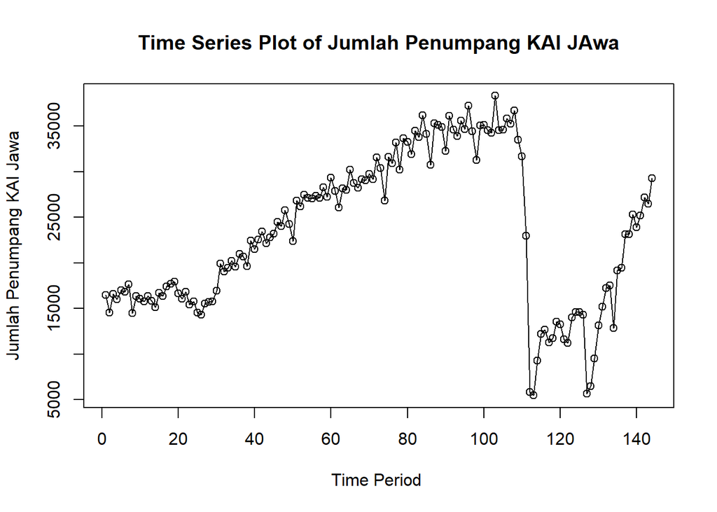

```r
ts.plot(data.ts, xlab="Time Period ", ylab="Jumlah Penumpang KAI Jawa",
        main = "Time Series Plot of Jumlah Penumpang KAI JAwa")
points(data.ts)
```

Plot deret waktu di atas menunjukkan bahwa data memiliki pola tren atau tidak stasioner dalam rataan.

#### Plot ACF

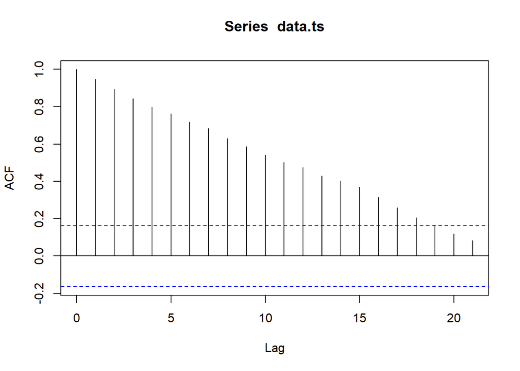

```r
acf(data.ts)
```

Berdasarkan plot ACF, data tersebut menunjukkan tails off slowly yang artinya data tidak statsioner dalam rataan.

#### Uji ADF

$H_0$ : Data tidak stasioner dalam rataan

$H_1$ : Data stasioner dalam rataan

```r
tseries::adf.test(data.ts)
```

```
##
##  Augmented Dickey-Fuller Test
##
## data:  data.ts
## Dickey-Fuller = -1.8249, Lag order = 5, p-value = 0.6493
## alternative hypothesis: stationary
```

Berdasarkan Uji ADF yang telah dilakukan pada data, didapatkan nilai p-value sebesar 0.6493 sehingga terima $H_0$ artinya data tidak stasioner dalam rataan.

#### Plot Box-Cox

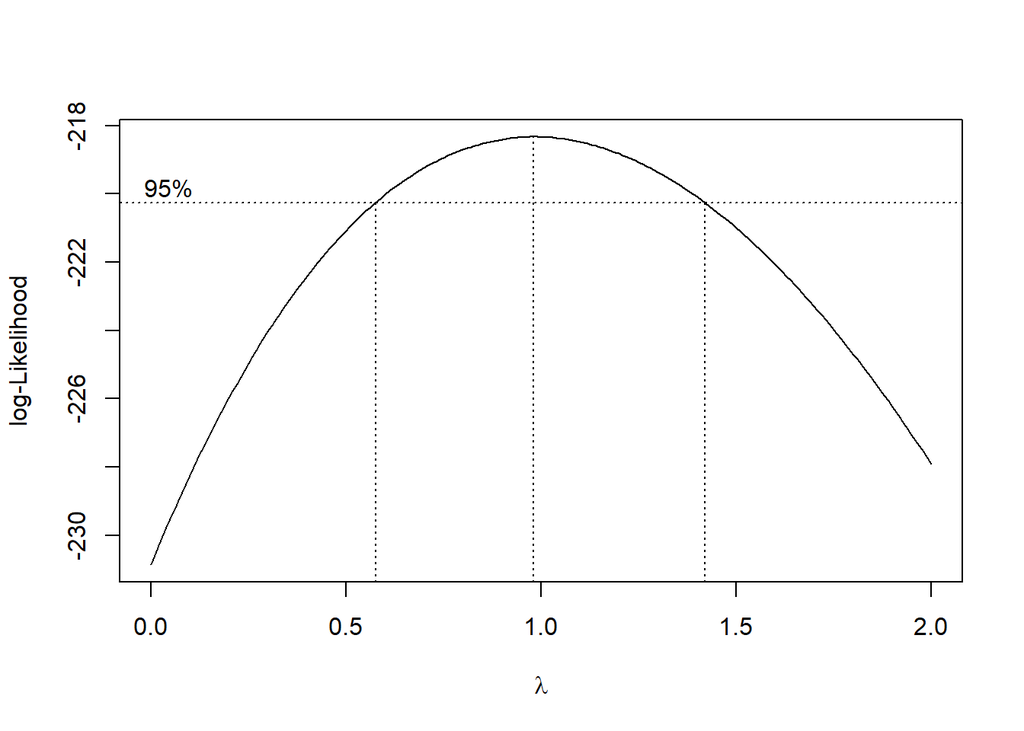

```r
index <- seq(1:144)
bc = boxcox(data.ts~index, lambda = seq(0,2,by=0.01))
```

```r
#Nilai Rounded Lambda
lambda <- bc$x[which.max(bc$y)]
lambda
```

```
## [1] 0.98
```

```r
#SK
bc$x[bc$y > max(bc$y) - 1/2 * qchisq(.95,1)]
```

```
##  [1] 0.58 0.59 0.60 0.61 0.62 0.63 0.64 0.65 0.66 0.67 0.68 0.69 0.70 0.71 0.72
## [16] 0.73 0.74 0.75 0.76 0.77 0.78 0.79 0.80 0.81 0.82 0.83 0.84 0.85 0.86 0.87
## [31] 0.88 0.89 0.90 0.91 0.92 0.93 0.94 0.95 0.96 0.97 0.98 0.99 1.00 1.01 1.02
## [46] 1.03 1.04 1.05 1.06 1.07 1.08 1.09 1.10 1.11 1.12 1.13 1.14 1.15 1.16 1.17
## [61] 1.18 1.19 1.20 1.21 1.22 1.23 1.24 1.25 1.26 1.27 1.28 1.29 1.30 1.31 1.32
## [76] 1.33 1.34 1.35 1.36 1.37 1.38 1.39 1.40 1.41
```

Pada gambar terlihat bahwa nilai $\lambda$ optimum sebesar 0.98 dan pada selang kepercayaan 95%. Batas bawah selang kepercayaan berada di 0.58 dan batas atas selang kepercayaannya berada di 1.41. Namun, pada selang tersebut memuat satu maka data dapat diartikan stasioner dalam ragam.

### Data Partisi 1

```r
dt1 <- data.ts[1:30] |> ts()
mean(dt1)
```

```
## [1] 16156.53
```

```r
var(dt1)
```

```
## [1] 917527.8
```

#### Plot Time Series

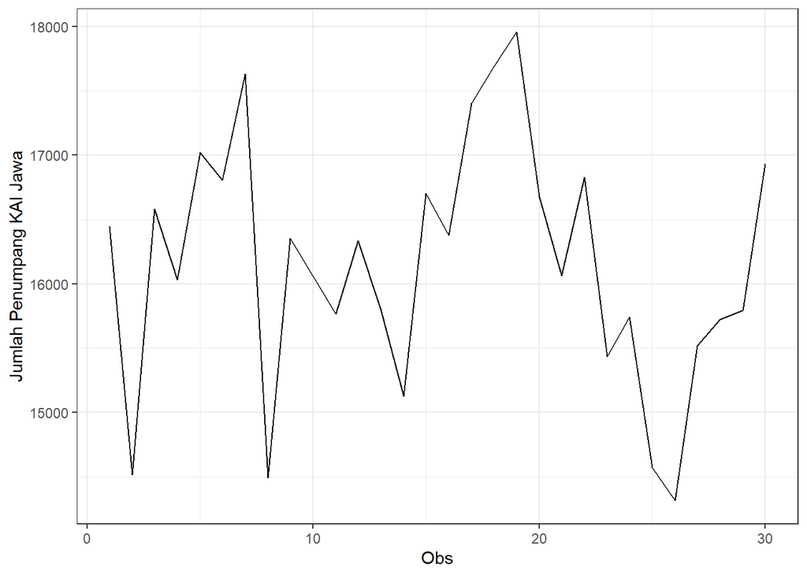

```r
dt1 |> as_tsibble() |>
  ggplot(aes(x = index, y = value)) +
  geom_line() + theme_bw() +
  xlab("Obs") + ylab("Jumlah Penumpang KAI Jawa")
```

Pada plot tersebut, data cenderung terlihat stasioner dalam ragam. Hal tersebut ditandai dengan data yang fluktuatif namun tidak selalu menybar disekitar nilai rataannya, yaitu 16156.53.

#### Plot ACF

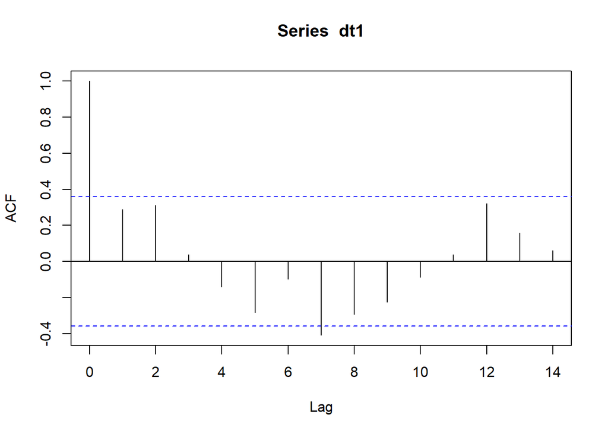

```r
acf(dt1)
```

Plot ACF tersebut tails off dan membentuk gelombang sinus.

#### Uji ADF

$H_0$ : Data tidak stasioner dalam rataan

$H_1$ : Data stasioner dalam rataan

```r
tseries::adf.test(dt1)
```

```
##
##  Augmented Dickey-Fuller Test
##
## data:  dt1
## Dickey-Fuller = -2.5968, Lag order = 3, p-value = 0.3434
## alternative hypothesis: stationary
```

Berdasarkan Uji ADF yang telah dilakukan pada data, didapatkan nilai p-value sebesar 0.3434 sehingga terima $H_0$ artinya data tidak stasioner dalam rataan.

#### Plot Box-Cox

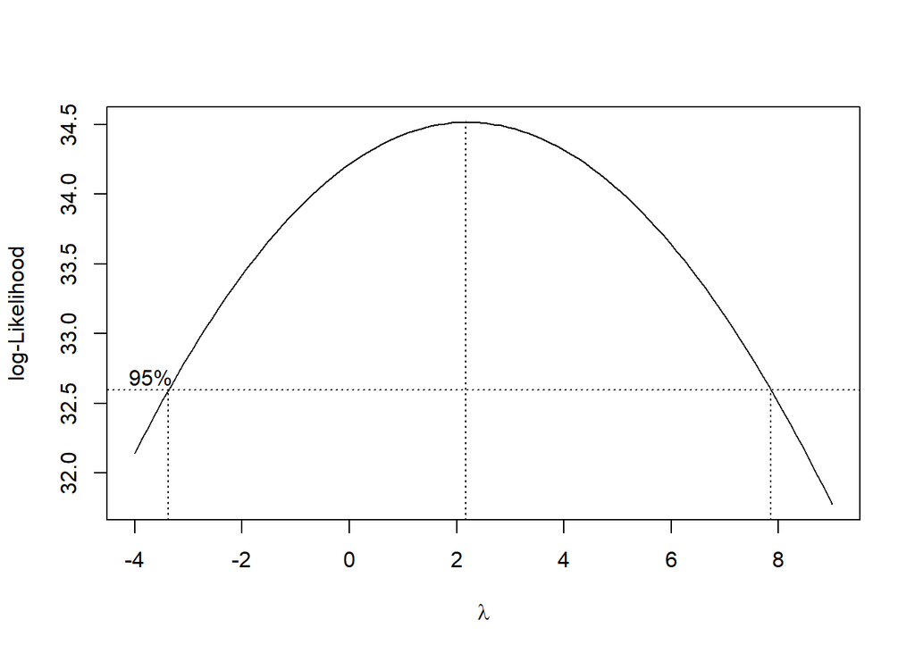

```r
index <- seq(1:30)
bc = boxcox(dt1~index, lambda = seq(-4,9,by=1))
```

```r
#Nilai Rounded Lambda
lambda <- bc$x[which.max(bc$y)]
lambda
```

```
## [1] 2.171717
```

```r
#SK
bc$x[bc$y > max(bc$y) - 1/2 * qchisq(.95,1)]
```

```
##  [1] -3.34343434 -3.21212121 -3.08080808 -2.94949495 -2.81818182 -2.68686869
##  [7] -2.55555556 -2.42424242 -2.29292929 -2.16161616 -2.03030303 -1.89898990
## [13] -1.76767677 -1.63636364 -1.50505051 -1.37373737 -1.24242424 -1.11111111
## [19] -0.97979798 -0.84848485 -0.71717172 -0.58585859 -0.45454545 -0.32323232
## [25] -0.19191919 -0.06060606  0.07070707  0.20202020  0.33333333  0.46464646
## [31]  0.59595960  0.72727273  0.85858586  0.98989899  1.12121212  1.25252525
## [37]  1.38383838  1.51515152  1.64646465  1.77777778  1.90909091  2.04040404
## [43]  2.17171717  2.30303030  2.43434343  2.56565657  2.69696970  2.82828283
## [49]  2.95959596  3.09090909  3.22222222  3.35353535  3.48484848  3.61616162
## [55]  3.74747475  3.87878788  4.01010101  4.14141414  4.27272727  4.40404040
## [61]  4.53535354  4.66666667  4.79797980  4.92929293  5.06060606  5.19191919
## [67]  5.32323232  5.45454545  5.58585859  5.71717172  5.84848485  5.97979798
## [73]  6.11111111  6.24242424  6.37373737  6.50505051  6.63636364  6.76767677
## [79]  6.89898990  7.03030303  7.16161616  7.29292929  7.42424242  7.55555556
## [85]  7.68686869  7.81818182
```

### Data Partisi 2

```r
dt2 <- data.ts[1:100] |> ts()
mean(dt2)
```

```
## [1] 24795.12
```

```r
var(dt2)
```

```
## [1] 50811535
```

#### Plot Time Series

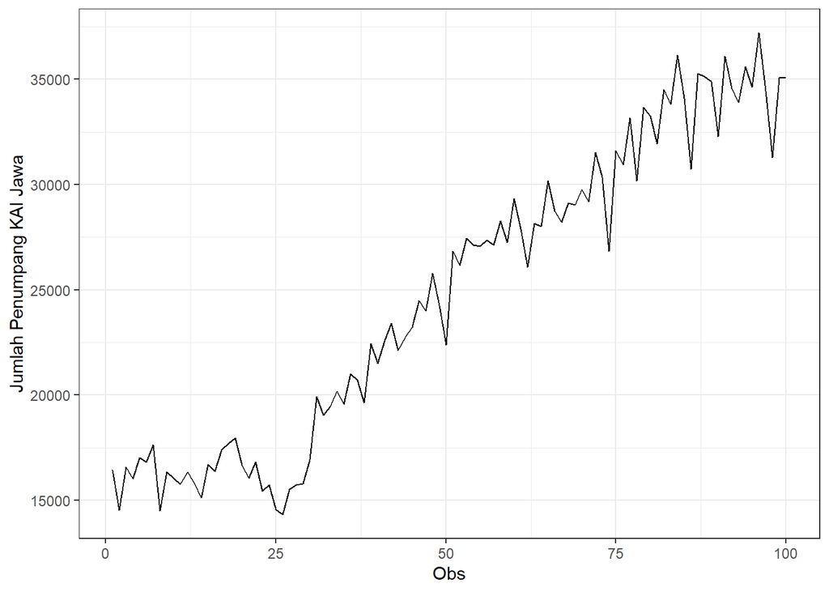

```r
dt2 |> as_tsibble() |>
  ggplot(aes(x = index, y = value)) +
  geom_line() + theme_bw() +
  xlab("Obs") + ylab("Jumlah Penumpang KAI Jawa")
```

Pada plot tersebut, terlihat bahawa data cendurung memiliki plot tren.

#### Plot ACF

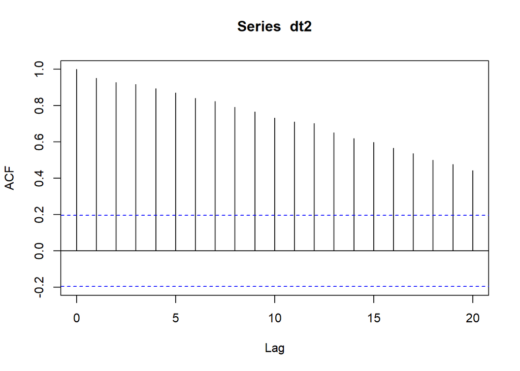

```r
acf(dt2)
```

Berdasarkan plot ACF, data tersebut menunjukkan tails off slowly yang artinya data tidak statsioner dalam rataan.

#### Uji ADF

$H_0$ : Data tidak stasioner dalam rataan

$H_1$ : Data stasioner dalam rataan

```r
adf.test(dt2)
```

```
##
##  Augmented Dickey-Fuller Test
##
## data:  dt2
## Dickey-Fuller = -2.2676, Lag order = 4, p-value = 0.4658
## alternative hypothesis: stationary
```

Berdasarkan Uji ADF yang telah dilakukan pada data, didapatkan nilai p-value sebesar 0.4658 sehingga terima $H_0$ artinya data tidak stasioner dalam rataan.

#### Plot Box-Cox

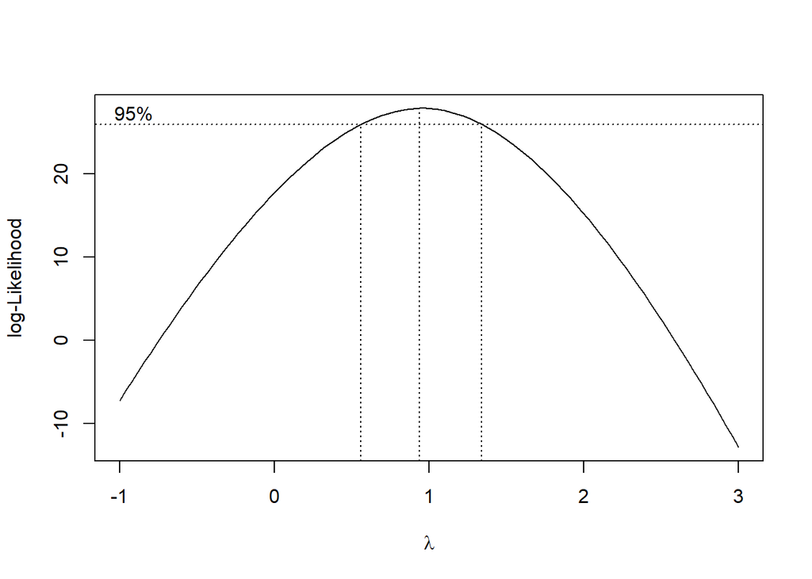

```r
index <- seq(1:100)
bc = boxcox(dt2~index, lambda = seq(-1,3,by=1))
```

```r
#Nilai Rounded Lambda
lambda <- bc$x[which.max(bc$y)]
lambda
```

```
## [1] 0.9393939
```

```r
#SK
bc$x[bc$y > max(bc$y) - 1/2 * qchisq(.95,1)]
```

```
##  [1] 0.5757576 0.6161616 0.6565657 0.6969697 0.7373737 0.7777778 0.8181818
##  [8] 0.8585859 0.8989899 0.9393939 0.9797980 1.0202020 1.0606061 1.1010101
## [15] 1.1414141 1.1818182 1.2222222 1.2626263 1.3030303
```